# Product Analysis

Mukhtaar Ismail

2024-09-10

## Install and load necessary packages.

I’ll use “tidyverse” package because of there a lot of important packages include dplyr package wich we will use data manipulation.

```r
require("tidyverse")
#install.packages("tidyverse")
#install.packages("naniar") # for dealing missing data (NA) data
#install.packages("SmartEDA")
#install.packages("ggcorrplot")

# Load necessary library
library("tidyverse")
library("lubridate")
library("magrittr")  # provides pipe operator, %>%, which allows you to chain functions together
library("naniar")    # exploring and dealing missing data
#library("dlookr")  # To visualizes the histogram of numeric data or relationship to specific categorical data. I don't use here
library("SmartEDA")
library("ggcorrplot")
```

## LET’S LOAD THE DATASET

```r
# read the data
store <-read.csv("Data/DEPARTMENTAL_STORE.csv")
head(store)
```

```
##   UNIQUE_ID            PRODUCT_NAME COMPANY      PRODUCT_TYPE PRODUCT_CATEGORY
## 1     GSK01                 A Masks       A           hygiene             mask
## 2     GSK02 N hand sanitizer,350 ml       N           hygiene        sanitizer
## 3     GSK03       G Channa Dal, 1kG       G foodgrains&spices      pulses(dal)
## 4     GSK04  I Organic Raisins,100g       I      Organic food       Dry Fruits
## 5     GSK05              S Body oil       S   beauty products         bodycare
## 6     GSK06          S AloeverS Gel       S   beauty products         bodycare
##   COST_PRICE SELLING_PRICE QUANTITY_DEMANDED
## 1     160.00        200.00               890
## 2     248.00        400.00               800
## 3     162.00        180.00               456
## 4      77.14        133.00               100
## 5     494.50        593.40               111
## 6     445.05        534.06               111
```

## Let’s Manipulate and Transform data

### let’s glimpse the data to know more about the structure of the data

```r
str(store)
```

```
## 'data.frame':    550 obs. of  8 variables:
##  $ UNIQUE_ID        : chr  "GSK01" "GSK02" "GSK03" "GSK04" ...
##  $ PRODUCT_NAME     : chr  "A Masks" "N hand sanitizer,350 ml" "G Channa Dal, 1kG" "I Organic Raisins,100g" ...
##  $ COMPANY          : chr  "A" "N" "G" "I" ...
##  $ PRODUCT_TYPE     : chr  "hygiene" "hygiene" "foodgrains&spices" "Organic food" ...
##  $ PRODUCT_CATEGORY : chr  "mask" "sanitizer" "pulses(dal)" "Dry Fruits" ...
##  $ COST_PRICE       : num  160 248 162 77.1 494.5 ...
##  $ SELLING_PRICE    : num  200 400 180 133 593 ...
##  $ QUANTITY_DEMANDED: int  890 800 456 100 111 111 360 52 27 353 ...
```

```r
glimpse(store)
```

```
## Rows: 550
## Columns: 8
## $ UNIQUE_ID         <chr> "GSK01", "GSK02", "GSK03", "GSK04", "GSK05", "GSK06"…
## $ PRODUCT_NAME      <chr> "A Masks", "N hand sanitizer,350 ml", "G Channa Dal,…
## $ COMPANY           <chr> "A", "N", "G", "I", "S", "S", "S", "G", "Z", "A", "Z…
## $ PRODUCT_TYPE      <chr> "hygiene", "hygiene", "foodgrains&spices", "Organic …
## $ PRODUCT_CATEGORY  <chr> "mask", "sanitizer", "pulses(dal)", "Dry Fruits", "b…
## $ COST_PRICE        <dbl> 160.00, 248.00, 162.00, 77.14, 494.50, 445.05, 270.0…
## $ SELLING_PRICE     <dbl> 200.000, 400.000, 180.000, 133.000, 593.400, 534.060…
## $ QUANTITY_DEMANDED <int> 890, 800, 456, 100, 111, 111, 360, 52, 27, 353, 500,…
```

```r
dim(store)
```

```
## [1] 550   8
```

There is 550 rows and 8 variables. ‘COMPANY’ and ‘PRODUCT_TYPE’ variables are chr type instead of factor, let’s convert into factor type.

```r
store$COMPANY <- as.factor(store$COMPANY)
store$PRODUCT_TYPE <- as.factor(store$PRODUCT_TYPE)

# let's view the data type
glimpse(store) # both now are factor type
```

```
## Rows: 550
## Columns: 8
## $ UNIQUE_ID         <chr> "GSK01", "GSK02", "GSK03", "GSK04", "GSK05", "GSK06"…
## $ PRODUCT_NAME      <chr> "A Masks", "N hand sanitizer,350 ml", "G Channa Dal,…
## $ COMPANY           <fct> A, N, G, I, S, S, S, G, Z, A, Z, I, E, N, A, J, Z, Z…
## $ PRODUCT_TYPE      <fct> hygiene, hygiene, foodgrains&spices, Organic food, b…
## $ PRODUCT_CATEGORY  <chr> "mask", "sanitizer", "pulses(dal)", "Dry Fruits", "b…
## $ COST_PRICE        <dbl> 160.00, 248.00, 162.00, 77.14, 494.50, 445.05, 270.0…
## $ SELLING_PRICE     <dbl> 200.000, 400.000, 180.000, 133.000, 593.400, 534.060…
## $ QUANTITY_DEMANDED <int> 890, 800, 456, 100, 111, 111, 360, 52, 27, 353, 500,…
```

Now the two variables are factor type.

### Adding columns in data

```r
# Define start and end dates
start_date <- ymd_hms("2020-05-01 00:00:00")
end_date <- ymd_hms("2020-05-31 23:00:00")

# Generate sequence of datetime values in hourly intervals
datetime_sequence <- seq(start_date, end_date, by = "hour")

#create datetime column in store
store <- mutate(store, Datetime = datetime_sequence[1:550])
head(store)
```

```
##   UNIQUE_ID            PRODUCT_NAME COMPANY      PRODUCT_TYPE PRODUCT_CATEGORY
## 1     GSK01                 A Masks       A           hygiene             mask
## 2     GSK02 N hand sanitizer,350 ml       N           hygiene        sanitizer
## 3     GSK03       G Channa Dal, 1kG       G foodgrains&spices      pulses(dal)
## 4     GSK04  I Organic Raisins,100g       I      Organic food       Dry Fruits
## 5     GSK05              S Body oil       S   beauty products         bodycare
## 6     GSK06          S AloeverS Gel       S   beauty products         bodycare
##   COST_PRICE SELLING_PRICE QUANTITY_DEMANDED            Datetime
## 1     160.00        200.00               890 2020-05-01 00:00:00
## 2     248.00        400.00               800 2020-05-01 01:00:00
## 3     162.00        180.00               456 2020-05-01 02:00:00
## 4      77.14        133.00               100 2020-05-01 03:00:00
## 5     494.50        593.40               111 2020-05-01 04:00:00
## 6     445.05        534.06               111 2020-05-01 05:00:00
```

#### let’s add one more columns to show profit, profit percent, and net profit of the products.

```r
# add column to show the profit
store <- store %>% mutate(PROFIT= SELLING_PRICE - COST_PRICE)

# add column to show the profit percent
store <- store %>% mutate(PROFIT_PERCENT= (PROFIT / COST_PRICE) *100)

# add column to show the net profit
store <- store %>% mutate(NET_PROFIT=PROFIT*QUANTITY_DEMANDED)

head(store)
```

```
##   UNIQUE_ID            PRODUCT_NAME COMPANY      PRODUCT_TYPE PRODUCT_CATEGORY
## 1     GSK01                 A Masks       A           hygiene             mask
## 2     GSK02 N hand sanitizer,350 ml       N           hygiene        sanitizer
## 3     GSK03       G Channa Dal, 1kG       G foodgrains&spices      pulses(dal)
## 4     GSK04  I Organic Raisins,100g       I      Organic food       Dry Fruits
## 5     GSK05              S Body oil       S   beauty products         bodycare
## 6     GSK06          S AloeverS Gel       S   beauty products         bodycare
##   COST_PRICE SELLING_PRICE QUANTITY_DEMANDED            Datetime PROFIT
## 1     160.00        200.00               890 2020-05-01 00:00:00  40.00
## 2     248.00        400.00               800 2020-05-01 01:00:00 152.00
## 3     162.00        180.00               456 2020-05-01 02:00:00  18.00
## 4      77.14        133.00               100 2020-05-01 03:00:00  55.86
## 5     494.50        593.40               111 2020-05-01 04:00:00  98.90
## 6     445.05        534.06               111 2020-05-01 05:00:00  89.01
##   PROFIT_PERCENT NET_PROFIT
## 1       25.00000   35600.00
## 2       61.29032  121600.00
## 3       11.11111    8208.00
## 4       72.41379    5586.00
## 5       20.00000   10977.90
## 6       20.00000    9880.11
```

### Rearrarange Columns Order Using dplyr’s Relocate Function.

Rearranging columns in a meaningful order can make analyses simpler. Let’s put datetime column in the first column.

```r
store <- store %>% relocate(Datetime, .before = UNIQUE_ID)
head(store)
```

```
##              Datetime UNIQUE_ID            PRODUCT_NAME COMPANY
## 1 2020-05-01 00:00:00     GSK01                 A Masks       A
## 2 2020-05-01 01:00:00     GSK02 N hand sanitizer,350 ml       N
## 3 2020-05-01 02:00:00     GSK03       G Channa Dal, 1kG       G
## 4 2020-05-01 03:00:00     GSK04  I Organic Raisins,100g       I
## 5 2020-05-01 04:00:00     GSK05              S Body oil       S
## 6 2020-05-01 05:00:00     GSK06          S AloeverS Gel       S
##        PRODUCT_TYPE PRODUCT_CATEGORY COST_PRICE SELLING_PRICE QUANTITY_DEMANDED
## 1           hygiene             mask     160.00        200.00               890
## 2           hygiene        sanitizer     248.00        400.00               800
## 3 foodgrains&spices      pulses(dal)     162.00        180.00               456
## 4      Organic food       Dry Fruits      77.14        133.00               100
## 5   beauty products         bodycare     494.50        593.40               111
## 6   beauty products         bodycare     445.05        534.06               111
##   PROFIT PROFIT_PERCENT NET_PROFIT
## 1  40.00       25.00000   35600.00
## 2 152.00       61.29032  121600.00
## 3  18.00       11.11111    8208.00
## 4  55.86       72.41379    5586.00
## 5  98.90       20.00000   10977.90
## 6  89.01       20.00000    9880.11
```

### DEALING WITH MISSING VALUE

Identifying the Pattern of Missing Values When exploring a new dataset, it’s worthwhile to identify the pattern of missing values. The `summary()` includes the number of missing values for each column along with the summary statistics.

```r
summary(store)
```

```
##     Datetime                    UNIQUE_ID         PRODUCT_NAME
##  Min.   :2020-05-01 00:00:00   Length:550         Length:550
##  1st Qu.:2020-05-06 17:15:00   Class :character   Class :character
##  Median :2020-05-12 10:30:00   Mode  :character   Mode  :character
##  Mean   :2020-05-12 10:30:00
##  3rd Qu.:2020-05-18 03:45:00
##  Max.   :2020-05-23 21:00:00
##
##     COMPANY               PRODUCT_TYPE PRODUCT_CATEGORY     COST_PRICE
##  S      : 97   beauty products  :100   Length:550         Min.   :  9.00
##  G      : 84   foodgrains&spices: 91   Class :character   1st Qu.: 72.97
##  Z      : 66   Packed Food      : 84   Mode  :character   Median :180.06
##  A      : 57   Organic food     : 82                      Mean   :216.53
##  B      : 53   snacks           : 64                      3rd Qu.:320.54
##  I      : 36   hygiene          : 54                      Max.   :912.00
##  (Other):157   (Other)          : 75
##  SELLING_PRICE    QUANTITY_DEMANDED     PROFIT       PROFIT_PERCENT
##  Min.   :  10.0   Min.   :   2.0    Min.   :  0.66   Min.   : 5.00
##  1st Qu.:  98.5   1st Qu.: 120.0    1st Qu.: 18.71   1st Qu.:15.00
##  Median : 229.0   Median : 316.0    Median : 41.16   Median :20.00
##  Mean   : 274.9   Mean   : 327.2    Mean   : 58.41   Mean   :29.82
##  3rd Qu.: 422.0   3rd Qu.: 500.0    3rd Qu.: 80.81   3rd Qu.:31.58
##  Max.   :1200.0   Max.   :1100.0    Max.   :288.00   Max.   :90.00
##
##    NET_PROFIT
##  Min.   :   223.4
##  1st Qu.:  4299.4
##  Median :  9350.0
##  Mean   : 12092.5
##  3rd Qu.: 13661.9
##  Max.   :136800.0
##
```

```r
# find to of missing values
sum_missing_values <- sum(is.na(store))
print(paste("The total of missing values are:", sum_missing_values))  # 0
```

```
## [1] "The total of missing values are: 0"
```

```r
# summary of missing variables
miss_var_summary(store)
```

```
## # A tibble: 12 × 3
##    variable          n_miss pct_miss
##    <chr>              <int>    <num>
##  1 Datetime               0        0
##  2 UNIQUE_ID              0        0
##  3 PRODUCT_NAME           0        0
##  4 COMPANY                0        0
##  5 PRODUCT_TYPE           0        0
##  6 PRODUCT_CATEGORY       0        0
##  7 COST_PRICE             0        0
##  8 SELLING_PRICE          0        0
##  9 QUANTITY_DEMANDED      0        0
## 10 PROFIT                 0        0
## 11 PROFIT_PERCENT         0        0
## 12 NET_PROFIT             0        0
```

As shown the result, there is no missing values. If a column has a large percentage of missing values, then you may want to consider dropping that column all together. However, if you are really interested in the effect of that column, then a better idea is to remove the observations that have missing values.

### Identifying Distinct Values Using dplyr’s Distinct Function

The `distinct` function returns only the unique values from a column.

```r
dim(distinct(store))
```

```
## [1] 550  12
```

As shown the result, all the values are unique.

### Save the updates file

```r
# Save up the updates for reusing. Uncomment if want to run
#write.table(store, file = "Updated_store_data.csv", sep=",")
```

## Let’s Spot patterns and problems using graphs and visualizations

What is the AVERAGE_QUANTITY of PRODUCT_TYPE

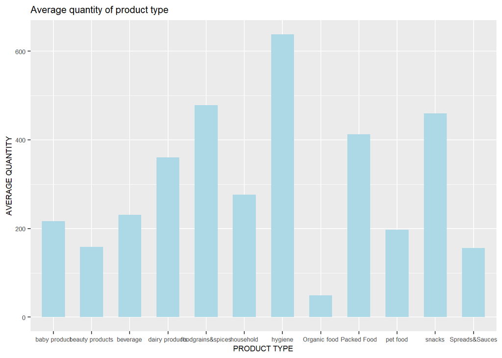

```r
#PLOT FOR AVERAGE_QUANTITY & PRODUCT_TYPE
store %>% group_by(PRODUCT_TYPE) %>%
  summarise(AVERAGE_QUANTITY=mean(QUANTITY_DEMANDED),
            AVERAGE_NET_PROFIT=mean(NET_PROFIT)) %>%
  ggplot(aes(x=PRODUCT_TYPE, y=AVERAGE_QUANTITY))+geom_col(width=0.6, fill="lightblue")+
  labs(x="PRODUCT TYPE", y="AVERAGE QUANTITY", title = "Average quantity of product type")+
  theme(text= element_text(size=8))
```

Let’s plot the Average Net Profit of Product Type

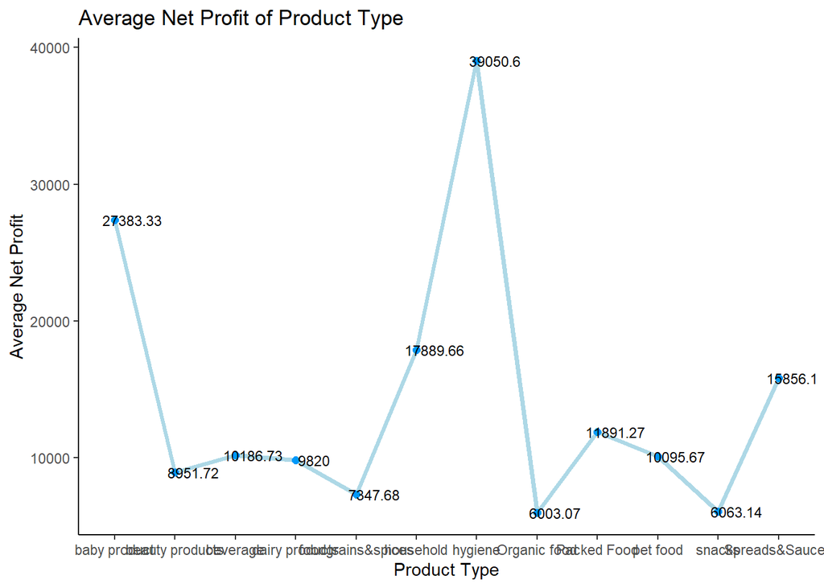

```r
store %>% group_by(PRODUCT_TYPE) %>%
  summarise(AVERAGE_NET_PROFIT=mean(NET_PROFIT)) %>%
  ggplot(aes(x=PRODUCT_TYPE, y= AVERAGE_NET_PROFIT, group = 3))+
  geom_line(color="lightblue", linewidth=1.3)+
  geom_point(color = "#0099f9", size = 2)+
  theme(text= element_text(size=7))+
  geom_text(aes(label = round(AVERAGE_NET_PROFIT,2)), nudge_x = 0.3,
            nudge_y = 0.2,
            size = 3)+
  theme_classic()+
  labs(x="Product Type", y="Average Net Profit", title = "Average Net Profit of Product Type")
```

Let’s plot the Average Quantity and Average Net Profit of Product Type

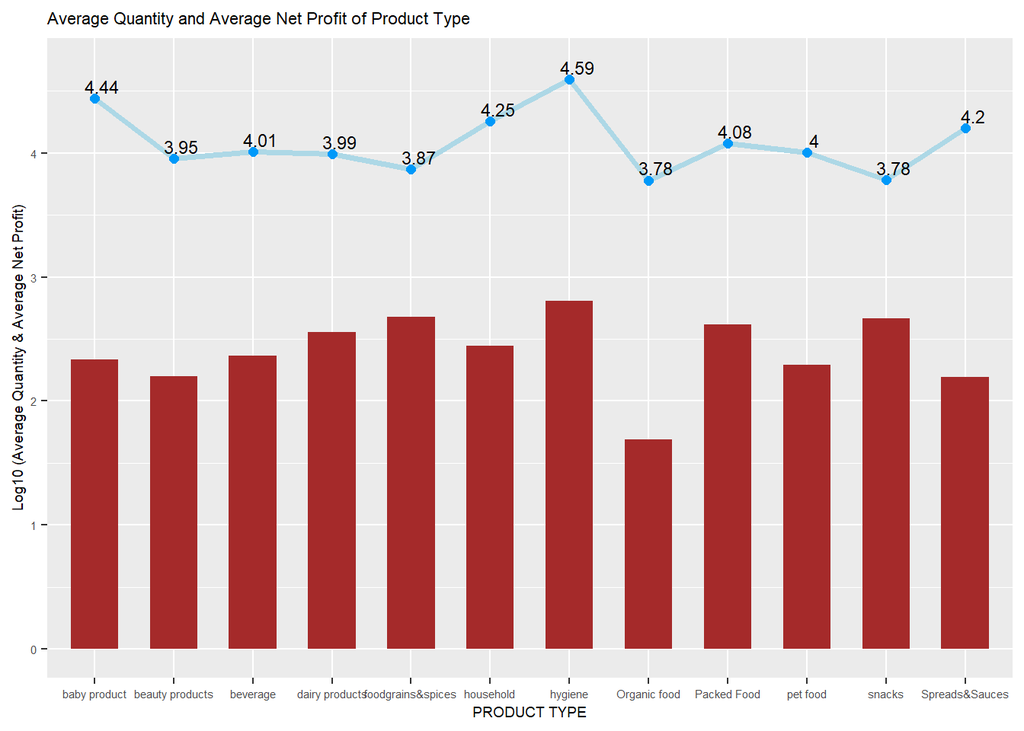

```r
#Average quantity and AVERAGE NET PROFIT  of product type
store %>% group_by(PRODUCT_TYPE) %>%
  summarise(AVERAGE_QUANTITY=mean(QUANTITY_DEMANDED),
            AVERAGE_NET_PROFIT=mean(NET_PROFIT)) %>%
  ggplot(aes(x=PRODUCT_TYPE))+
  geom_col(aes(y = log10(AVERAGE_QUANTITY)), width=0.6, fill="brown")+
  geom_line(aes(y=log10(AVERAGE_NET_PROFIT), group=1),color="lightblue", linewidth=1.3)+
  geom_point(aes(y = log10(AVERAGE_NET_PROFIT)),color = "#0099f9", size = 2)+
  geom_text(aes(y=log10(AVERAGE_NET_PROFIT),label =  round(log10(AVERAGE_NET_PROFIT),2)),
            nudge_x = 0.1,
            nudge_y = 0.1,
            size = 3)+
  theme(text= element_text(size=7))+
  labs(x="PRODUCT TYPE", y="Log10 (Average Quantity & Average Net Profit)", title = "Average Quantity and Average Net Profit of Product Type")
```

Plot histogram for QUANTITY DEMANDED of PRODUCT CATEGORY where PRODUCT TYPE is “snacks”

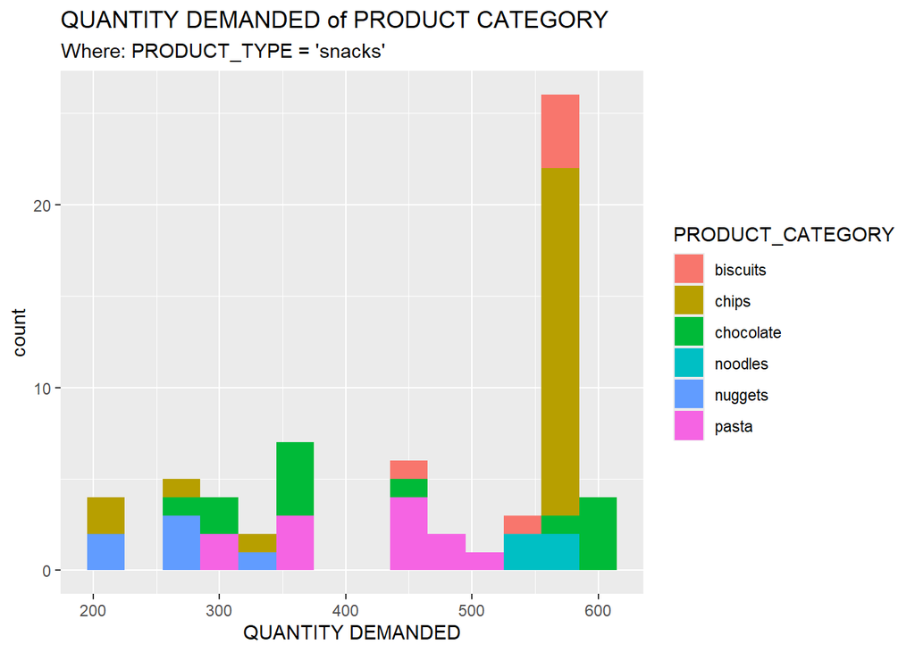

```r
# HISTOGRAM FOR QUANTITY_DEMANDED OF PRODUCT_CATEGORY WHERE PRODUCT_TYPE IS "snacks"
store %>%
  filter(PRODUCT_TYPE == "snacks") %>%
  ggplot(aes(x=QUANTITY_DEMANDED, fill=PRODUCT_CATEGORY))+geom_histogram(binwidth = 30)+
  labs(x="QUANTITY DEMANDED", title = "QUANTITY DEMANDED of PRODUCT CATEGORY",
       subtitle="Where: PRODUCT_TYPE = 'snacks'")
```

Plot average net profit for product type in each company

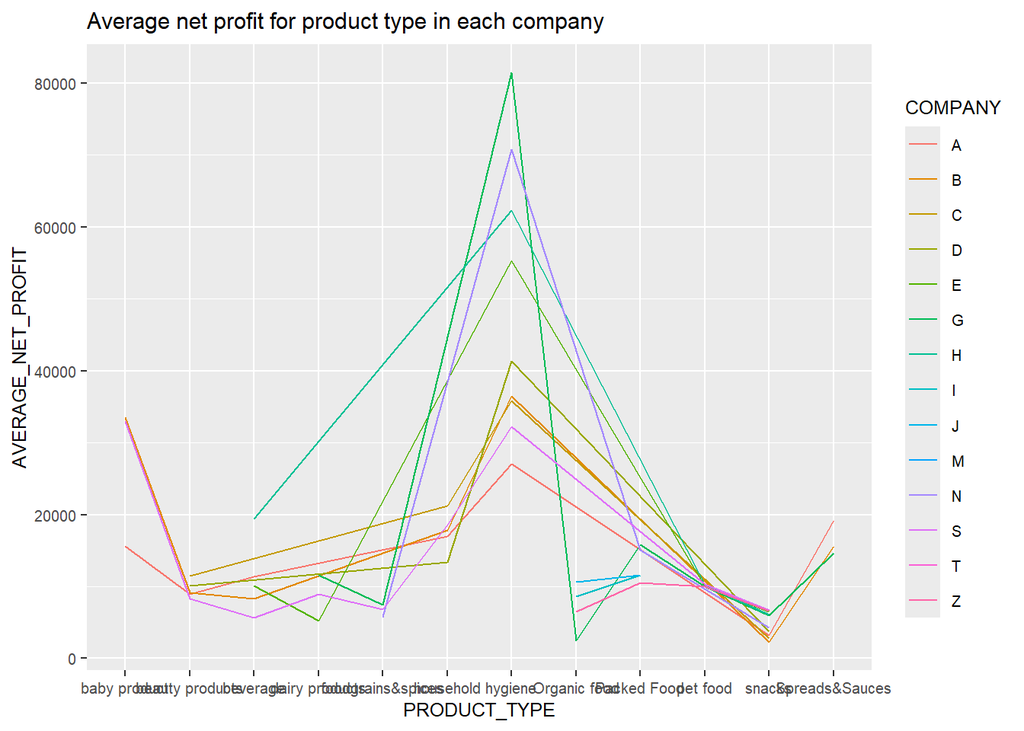

```r
# PLOT FOR AVERAGE_NET_PROFIT & COMPANY

store %>% group_by(PRODUCT_TYPE, COMPANY) %>%
  summarise(AVERAGE_NET_PROFIT=mean(NET_PROFIT, na.rm=TRUE)) %>%
  ggplot(aes(x=PRODUCT_TYPE, y=AVERAGE_NET_PROFIT, group=COMPANY, colour = COMPANY))+
  geom_line()+ theme(text= element_text(size=9.5))+
  ggtitle("Average net profit for product type in each company")
```

Let’s make a pie chart for each HYGIENE PRODUCT’S QUANTITY DEMANDED

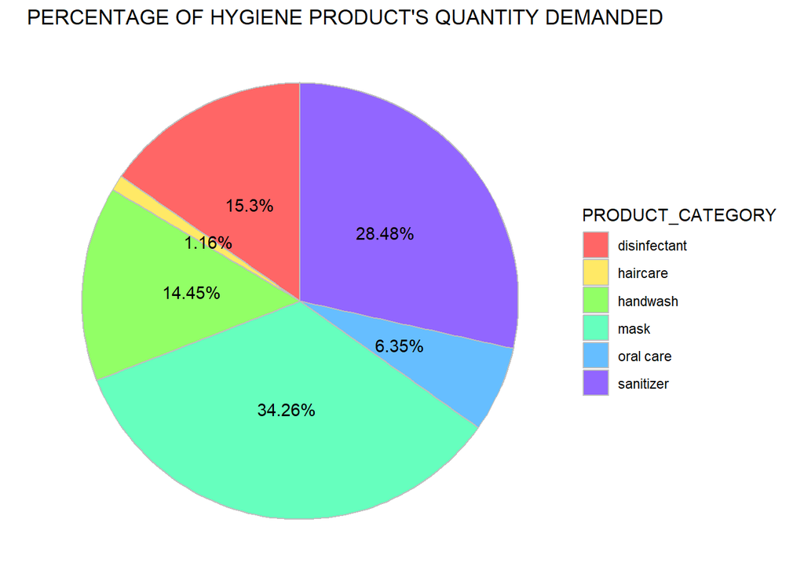

```r
#LET'S PREPARE REQUIRD DATA

hygiene_prod <-  store %>% filter(PRODUCT_TYPE=="hygiene")%>%
  group_by(PRODUCT_CATEGORY)%>%
  summarise(QUANTITY_DEMANDED=sum(QUANTITY_DEMANDED))

# LET'S CALCULATE PERCENTAGE OF EACH PRODUCT

hygiene_prod_perc <- hygiene_prod %>%
  arrange(desc(PRODUCT_CATEGORY)) %>%
  mutate(percentage=round(QUANTITY_DEMANDED*100/sum(QUANTITY_DEMANDED),2)) %>%
  mutate(y_pos = cumsum(percentage)-0.5*percentage)

# LET'S CREATE THE PIE CHART
hygiene_prod_perc %>% ggplot(aes(x="", percentage, fill = PRODUCT_CATEGORY))+
  geom_bar(width = 1, stat = "identity", color="grey", alpha=0.6)+
  coord_polar("y", start = 0)+
  geom_text(aes(y=y_pos, label = paste0(percentage, "%")), color="black")+
  scale_fill_manual(values = rainbow(7))+
  ggtitle("PERCENTAGE OF HYGIENE PRODUCT'S QUANTITY DEMANDED")+
  theme_void()
```

Plot a donut chart for same data

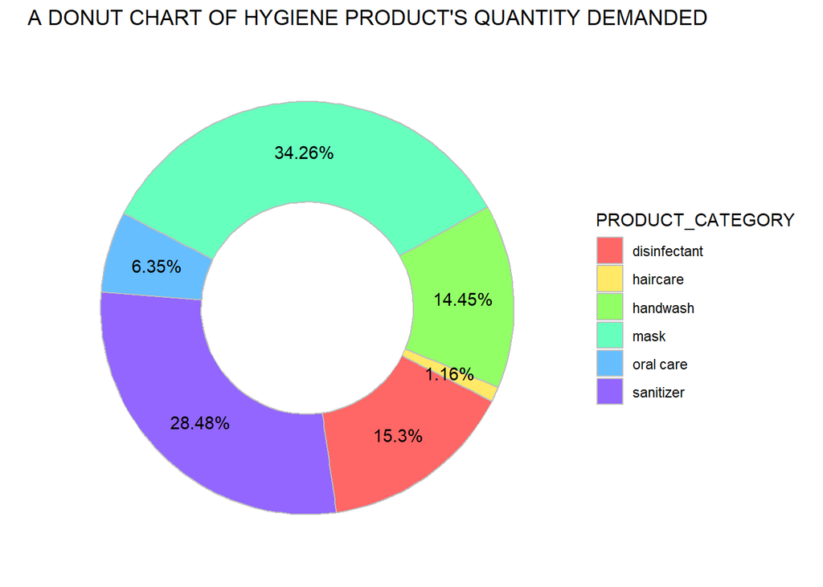

```r
# LET'S MAKE A DONUT FOR THE SAME DATA

hygiene_prod_perc %>% ggplot(aes(x=2, percentage, fill = PRODUCT_CATEGORY))+
  geom_bar(stat = "identity", color="grey", alpha=0.6)+
  coord_polar(theta = "y", start = 3)+
  geom_text(aes(y=y_pos, label = paste0(percentage, "%")), color="black")+
  ggtitle("A DONUT CHART OF HYGIENE PRODUCT'S QUANTITY DEMANDED")+
  scale_fill_manual(values = rainbow(7))+ theme_void() + xlim(0.6,2.6)
```

Correlation refers to the statistical concept that studies the relationship between two quantitative variables. Let’s find and plot the correlation martix of numerical variables using ggcorrplot package.

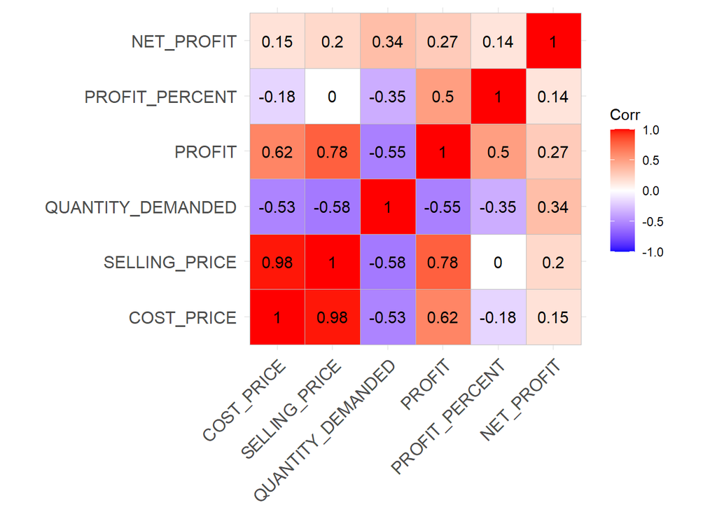

```r
numeric_var<- select_if(store, is.numeric) # get numerical features
r_corr<-cor(numeric_var, use = "complete.obs")

#PLOT THE CORRELATION MATRIX (HEAT MAP)
ggcorrplot(r_corr, lab = TRUE)
```

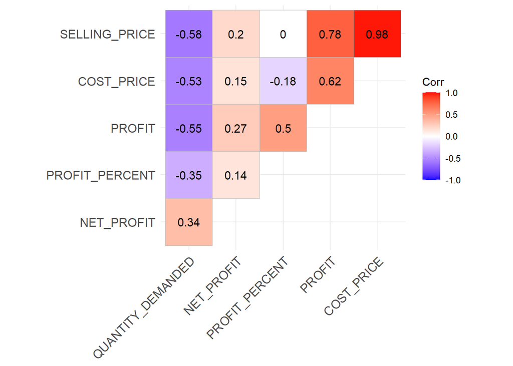

```r
# PLOT THE SORTED UPPER TRIANGLE HEAT MAP
ggcorrplot(r_corr,hc.order = TRUE, type = "upper", lab = TRUE)
```

Let’s know the distribution of some numerical variables.

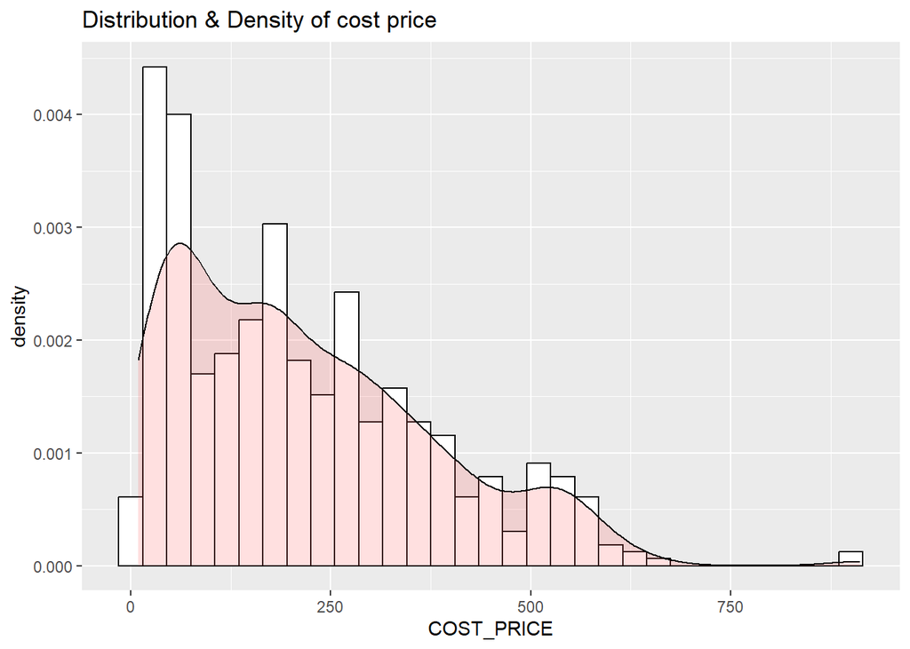

```r
# plot histogram & density of cost_price
ggplot(store, aes(x= COST_PRICE))+
  geom_histogram(aes(y=..density..), binwidth=30, colour="black", fill="white")+
  geom_density(alpha=.2, fill="#FF6666")+
  ggtitle("Distribution & Density of cost price")
```

Density and Distribution of numerical variables

```
## $`0`
```

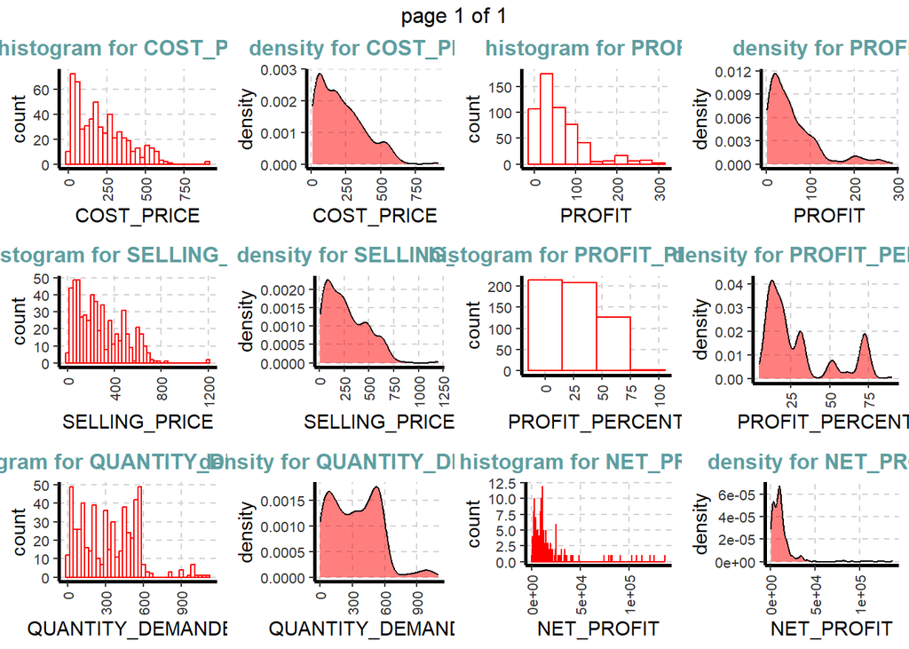

```r
numeric_var<- colnames(select_if(store, is.numeric))

ExpTwoPlots(store, iv_variables = numeric_var,
            lp_geom_type = "histogram",
            lp_arg_list=list(fill = "white",color = "red",  binwidth=30),
            rp_geom_type= "density",
            rp_arg_list = list(alpha=0.5, fill="red"),
            page = c(3,2)
            )
```

Let’s dive more about statistics in numerical variables using ExpNumStat() function in smartEDA package.

```r
ExpNumStat(store)
```

```
##               Vname Group  TN nNeg nZero nPos NegInf PosInf NA_Value
## 1        COST_PRICE   All 550    0     0  550      0      0        0
## 6        NET_PROFIT   All 550    0     0  550      0      0        0
## 4            PROFIT   All 550    0     0  550      0      0        0
## 5    PROFIT_PERCENT   All 550    0     0  550      0      0        0
## 3 QUANTITY_DEMANDED   All 550    0     0  550      0      0        0
## 2     SELLING_PRICE   All 550    0     0  550      0      0        0
##   Per_of_Missing        sum    min    max      mean  median        SD    CV
## 1              0  119091.37   9.00    912   216.530  180.06   161.829 0.747
## 6              0 6650871.60 223.44 136800 12092.494 9350.00 15220.272 1.259
## 4              0   32126.38   0.66    288    58.412   41.16    56.666 0.970
## 5              0   16402.13   5.00     90    29.822   20.00    21.719 0.728
## 3              0  179944.00   2.00   1100   327.171  316.00   224.432 0.686
## 2              0  151217.75  10.00   1200   274.941  229.00   202.085 0.735
##        IQR Skewness Kurtosis
## 1  247.570    0.876    0.469
## 6 9362.496    4.807   28.880
## 4   62.103    1.775    3.195
## 5   16.579    1.095   -0.240
## 3  380.000    0.564    0.230
## 2  323.500    0.837    0.547
```

The distribution of all numeric variables are right-tail distribution. As shown histogram and density in the above graph, there is other two ways I can confirm this claim. First, all mean of numerical variables are greater than their median, this indicates that the distribution is right-tailed. Secondly, all the skewness values are greater than 0, this shows this right-tailed distribution. There is highly positive skewness variables such NET_PROFIT, PROFIT_PERCENT , and PROFIT. and moderate skewness variables include COST_PRICE, SELLING_PRICE, and QUANTITY_DEMANDED.

In addition, the Kurtosis indicates the presence of outliers. Until now, there is one variable which have high Kurtosis value (NET_PROFIT). This shows there is more outliers in this variable, but I’ll confirm by plotting boxplot using smartEDA package.

```
## $`0`
```

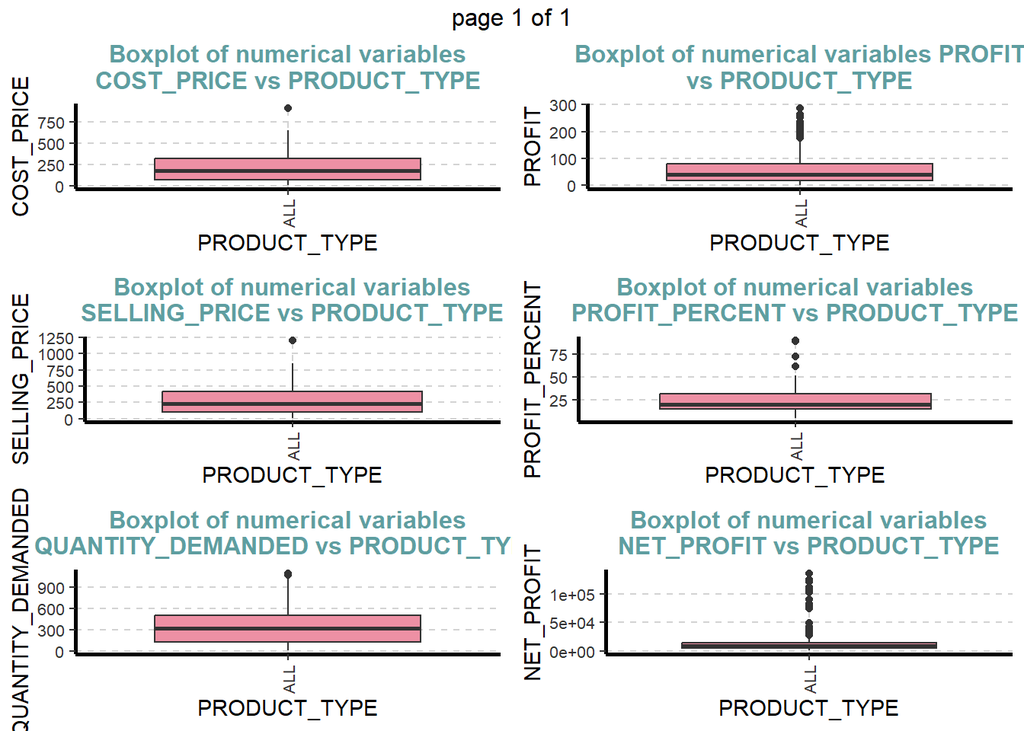

```r
ExpNumViz(store, target = "PRODUCT_TYPE",type = 3, Page = c(3,2), gtitle = "Boxplot of numerical variables")
```

As the result above shows, NET_PROFIT, PROFIT_PERCENT , and PROFIT have more outliers than other variables. Specialy, NET_PROFIT variable contain most outliers compared with others. This confirm the fact that NET_PROFIT has high Kurtosis value (28.8).

**Note:** If you are preparing this data for modeling, you need to solve and transform some of issues in variables like skewness of numerical variables and remove outliers.